# Modelling workshop: Session 2

## Session 2

**Session 2** contains an introduction to the **tidyverse** environment and an introduction to plotting in **ggplot**.

### Session 2a - Introduction to tidyverse

**tidyverse** is a package of packages (e.g. *dplyr*, *ggplot2*). *tidyverse* uses slightly different *syntax* (symbols, etc.) than what we have mostly been using, though we have seen some *ggplot* syntax. For example, pipes (**%>%**) are a convenient tool and we will use them below. One difference is when using tidyverse data are usually organised as **tibbles** or **tbl** instead of **data frames**. We will use them now to see how they are used. First, let’s look at an in-built data set, *diamonds*. Note there are actually a few ways that we can look at *diamonds* using different functions, a couple of which we saw in the **Session 1**:

```r
library(tidyverse)
head(diamonds)
```

```
## # A tibble: 6 × 10
##   carat cut       color clarity depth table price     x     y     z
##   <dbl> <ord>     <ord> <ord>   <dbl> <dbl> <int> <dbl> <dbl> <dbl>
## 1  0.23 Ideal     E     SI2      61.5    55   326  3.95  3.98  2.43
## 2  0.21 Premium   E     SI1      59.8    61   326  3.89  3.84  2.31
## 3  0.23 Good      E     VS1      56.9    65   327  4.05  4.07  2.31
## 4  0.29 Premium   I     VS2      62.4    58   334  4.2   4.23  2.63
## 5  0.31 Good      J     SI2      63.3    58   335  4.34  4.35  2.75
## 6  0.24 Very Good J     VVS2     62.8    57   336  3.94  3.96  2.48
```

```r
str(diamonds)
```

```
## tibble [53,940 × 10] (S3: tbl_df/tbl/data.frame)
##  $ carat  : num [1:53940] 0.23 0.21 0.23 0.29 0.31 0.24 0.24 0.26 0.22 0.23 ...
##  $ cut    : Ord.factor w/ 5 levels "Fair"<"Good"<..: 5 4 2 4 2 3 3 3 1 3 ...
##  $ color  : Ord.factor w/ 7 levels "D"<"E"<"F"<"G"<..: 2 2 2 6 7 7 6 5 2 5 ...
##  $ clarity: Ord.factor w/ 8 levels "I1"<"SI2"<"SI1"<..: 2 3 5 4 2 6 7 3 4 5 ...
##  $ depth  : num [1:53940] 61.5 59.8 56.9 62.4 63.3 62.8 62.3 61.9 65.1 59.4 ...
##  $ table  : num [1:53940] 55 61 65 58 58 57 57 55 61 61 ...
##  $ price  : int [1:53940] 326 326 327 334 335 336 336 337 337 338 ...
##  $ x      : num [1:53940] 3.95 3.89 4.05 4.2 4.34 3.94 3.95 4.07 3.87 4 ...
##  $ y      : num [1:53940] 3.98 3.84 4.07 4.23 4.35 3.96 3.98 4.11 3.78 4.05 ...
##  $ z      : num [1:53940] 2.43 2.31 2.31 2.63 2.75 2.48 2.47 2.53 2.49 2.39 ...
```

```r
glimpse(diamonds)
```

```
## Rows: 53,940
## Columns: 10
## $ carat   <dbl> 0.23, 0.21, 0.23, 0.29, 0.31, 0.24, 0.24, 0.26, 0.22, 0.23, 0.…
## $ cut     <ord> Ideal, Premium, Good, Premium, Good, Very Good, Very Good, Ver…
## $ color   <ord> E, E, E, I, J, J, I, H, E, H, J, J, F, J, E, E, I, J, J, J, I,…
## $ clarity <ord> SI2, SI1, VS1, VS2, SI2, VVS2, VVS1, SI1, VS2, VS1, SI1, VS1, …
## $ depth   <dbl> 61.5, 59.8, 56.9, 62.4, 63.3, 62.8, 62.3, 61.9, 65.1, 59.4, 64…
## $ table   <dbl> 55, 61, 65, 58, 58, 57, 57, 55, 61, 61, 55, 56, 61, 54, 62, 58…
## $ price   <int> 326, 326, 327, 334, 335, 336, 336, 337, 337, 338, 339, 340, 34…
## $ x       <dbl> 3.95, 3.89, 4.05, 4.20, 4.34, 3.94, 3.95, 4.07, 3.87, 4.00, 4.…
## $ y       <dbl> 3.98, 3.84, 4.07, 4.23, 4.35, 3.96, 3.98, 4.11, 3.78, 4.05, 4.…
## $ z       <dbl> 2.43, 2.31, 2.31, 2.63, 2.75, 2.48, 2.47, 2.53, 2.49, 2.39, 2.…
```

```r
view(diamonds)
```

Note what information the different ways of showing the data give you.

```r
filter(diamonds, cut=='Premium' & price >= 15000)
```

```
## # A tibble: 587 × 10
##    carat cut     color clarity depth table price     x     y     z
##    <dbl> <ord>   <ord> <ord>   <dbl> <dbl> <int> <dbl> <dbl> <dbl>
##  1  1.54 Premium E     VS2      62.3    58 15002  7.31  7.39  4.58
##  2  2.1  Premium I     SI1      61.5    57 15007  8.25  8.21  5.06
##  3  2.02 Premium G     SI2      63      59 15014  8.05  7.95  5.03
##  4  1.51 Premium E     VS2      60.1    58 15025  7.57  7.51  4.53
##  5  2.8  Premium I     SI2      61.1    59 15030  9.03  8.98  5.5
##  6  2.19 Premium I     SI2      60.8    60 15032  8.34  8.38  5.08
##  7  2.09 Premium J     VS1      61.2    59 15035  8.22  8.31  5.06
##  8  1.5  Premium D     VS2      60.2    59 15052  7.48  7.36  4.47
##  9  2.07 Premium I     SI2      60.5    60 15055  8.32  8.27  5.02
## 10  2.2  Premium J     VS1      61.7    59 15064  8.3   8.34  5.13
## # ℹ 577 more rows
```

Now let’s use the *tidyverse* syntax to find the *mean* *price* for the different *cut* diamonds using this code:

```r
diamonds %>%  # line 1
  group_by(cut) %>%  # line 2
  summarize(m = mean(price)) %>% # line 3
  ungroup() # line 4
```

```
## # A tibble: 5 × 2
##   cut           m
##   <ord>     <dbl>
## 1 Fair      4359.
## 2 Good      3929.
## 3 Very Good 3982.
## 4 Premium   4584.
## 5 Ideal     3458.
```

This R script is use the **%>%** operator from the **dplyr** package installed through in the **tidyverse** package to perform different tasks. In the code the lines:

1. tells R to take the *diamonds* dataset as the input data,
2. groups the dataset by the *cut* column,
3. calculates the mean of the *price* column for each group created by the second line, creating a new column called *m* to stores the mean values, and
4. removes the grouping, resetting the dataset to its original form.

Another example using an in built data set is:

```r
library(dplyr)
data(mtcars)

head(mtcars) # look at the data
```

```
##                    mpg cyl disp  hp drat    wt  qsec vs am gear carb
## Mazda RX4         21.0   6  160 110 3.90 2.620 16.46  0  1    4    4
## Mazda RX4 Wag     21.0   6  160 110 3.90 2.875 17.02  0  1    4    4
## Datsun 710        22.8   4  108  93 3.85 2.320 18.61  1  1    4    1
## Hornet 4 Drive    21.4   6  258 110 3.08 3.215 19.44  1  0    3    1
## Hornet Sportabout 18.7   8  360 175 3.15 3.440 17.02  0  0    3    2
## Valiant           18.1   6  225 105 2.76 3.460 20.22  1  0    3    1
```

```r
mtcars %>%
  select(mpg, cyl, hp) %>%
  filter(cyl == 4) %>%
  arrange(desc(hp))
```

```
##                 mpg cyl  hp
## Lotus Europa   30.4   4 113
## Volvo 142E     21.4   4 109
## Toyota Corona  21.5   4  97
## Merc 230       22.8   4  95
## Datsun 710     22.8   4  93
## Porsche 914-2  26.0   4  91
## Fiat 128       32.4   4  66
## Fiat X1-9      27.3   4  66
## Toyota Corolla 33.9   4  65
## Merc 240D      24.4   4  62
## Honda Civic    30.4   4  52
```

In this example we use the **dplyr** package and *mtcars* dataset and **select()** three columns called *mpg*, *cyl*, and *hp*, and choose only the rows where *cyl* equals *4* using **filter()**. We then sort the rows by *hp* in *descending order* with **desc()**.

To find the average of three columns (*mpg*, *cyl*, and *hp*) in the filtered *mtcars* dataset, we can add the **summarize()** function from the **dplyr** package to the end of the chain of commands:

```r
library(dplyr)
mtcars %>%
  select(mpg, cyl, hp) %>%
  filter(cyl == 4) %>%
  summarize(avg_mpg = mean(mpg),
            avg_cyl = mean(cyl),
            avg_hp = mean(hp))
```

```
##    avg_mpg avg_cyl   avg_hp
## 1 26.66364       4 82.63636
```

Note the output will show the average *mpg*, *cyl*, and *hp* as separate columns named *avg_mpg*, *avg_cyl*, and *avg_hp*, respectively. The *avg_cyl* mean is 4 because we selected only those rows in which *cyl* was 4 using the **filter()** function.

### Session 2b - Plotting in ggplot

We have already met **ggplot** so let’s just get started. Now we will start using some data more similar to what we might get from serological studies. We will simulate some data that could represent antibody titres from samples from three bats over three days.

```r
Bat <- c("N1", "N1", "N1",
         "N2", "N2", "N2",
         "N3", "N3", "N3") ## three bats, identified as N1, N2 and N3

Date <- c("2023-07-08", "2023-07-09", "2023-07-10",
          "2023-07-08", "2023-07-09", "2023-07-10",
          "2023-07-08", "2023-07-09", "2023-07-10") # these are dates

Titer <- c(rpois(3,50),
           rpois(3,60),
           rpois(3,70)) # these are possible antibody titres

## Creating an object
mydata <- tibble(Bat, Date, Titer)
```

We simulated the data using the **rpois()** function, which simulates data using a **Poisson distribution**, which is a **discrete probability distribution** that expresses the probability of a given number of events, which for this we are saying is an antibody titre. However, titres can be **continuous** data, but we will use integers for now.

Note that without using the **set.seed()** function, we will all have different plots because **rpois()** and the related functions usings a random number generator like **rbeta** or **rnorm** use **random number** generators. You can take a look by typing **?Distributions** in the console.

Let’s plot the titres by the individual bats, first by *Bat* as the x-axis:

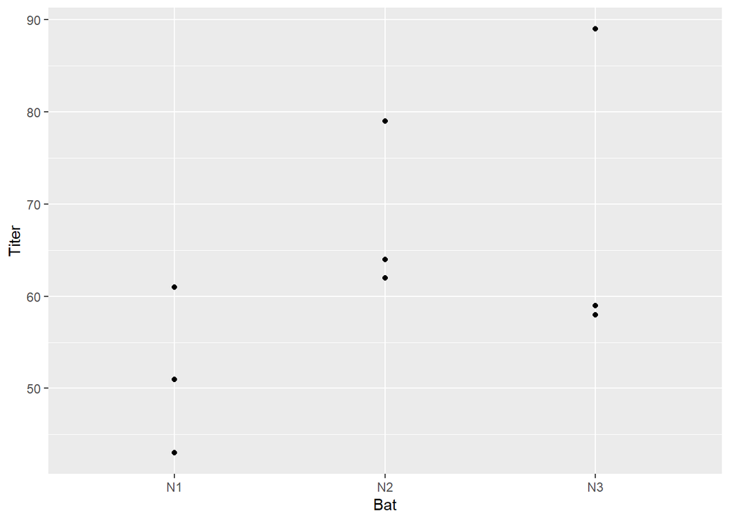

```r
library(ggplot2)
ggplot(mydata, aes(x = Bat, y = Titer)) +
  geom_point()
```

Second by *Date* as the x-axis:

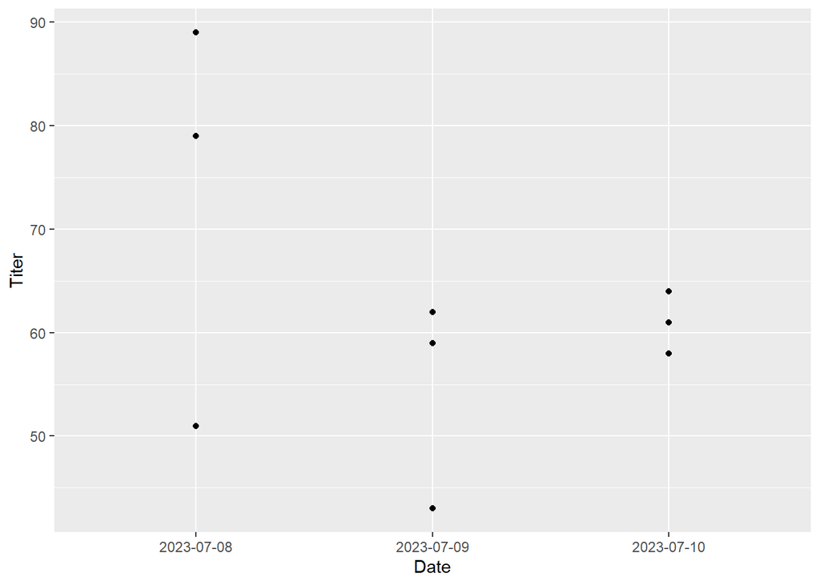

```r
library(ggplot2)
ggplot(mydata, aes(x = Date, y = Titer)) +
  geom_point()
```

Third by *Date* again as the x-axis, but colouring the titres by the individual bat identification:

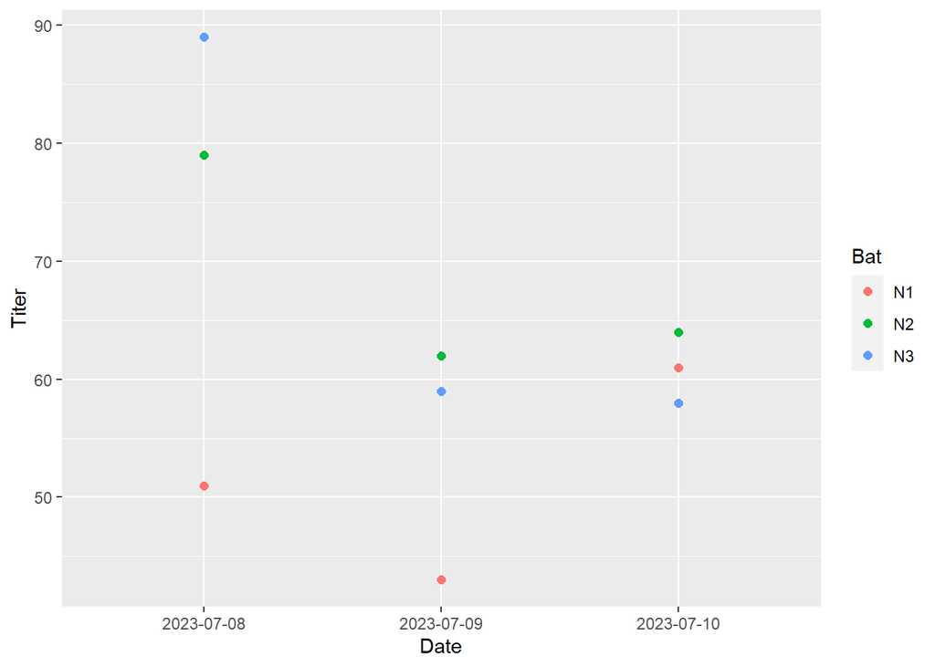

```r
library(ggplot2)
ggplot(mydata, aes(x = Date, y = Titer, colour = Bat)) +
  geom_point(size = 2)
```

We can plot the mean titre for each bat by using this method:

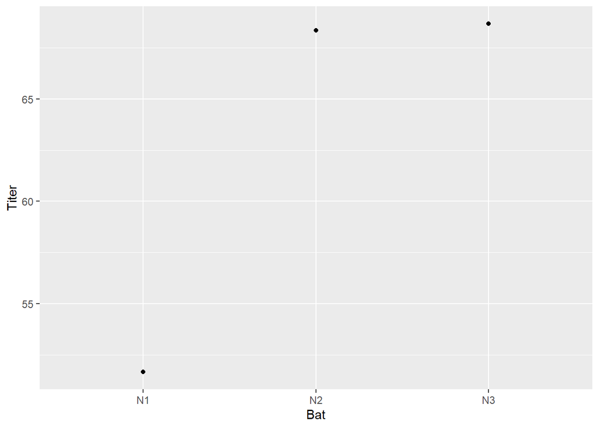

```r
ggplot(mydata, aes(x = Bat, y = Titer)) +
  stat_summary(fun = "mean", geom = "point")
```

Or by using this *tidyverse* syntax for it all:

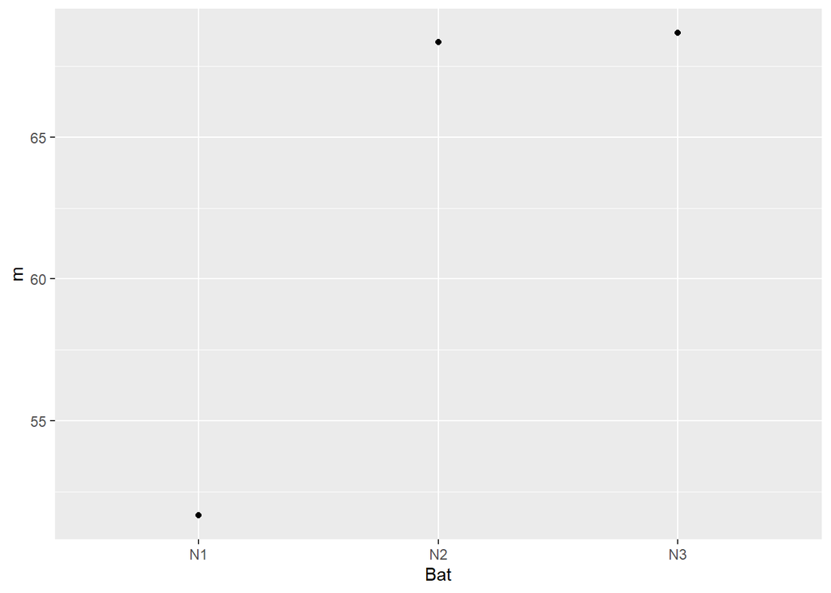

```r
mydata %>%                            # name of the dataset
  group_by(Bat) %>%                   # grouping the data
  summarize(m = mean(Titer)) %>%      # calculating the mean
  ungroup() %>%                       # ungrouping the data
  ggplot(aes(x = Bat, y = m)) +       # set up the graph
  geom_point()                        # add data points on graph
```

Now let’s increase the simulated data set size. This can be done simply, such as by replicating it using the **replicate()** function any number of times. Here we will replicate the above data three times using this code:

```r
library(dplyr)
mydata <- bind_rows(replicate(3, mydata, simplify = FALSE))
dim(mydata)
```

```
## [1] 27  3
```

Let’s plot that to see two things; what **replicate()** does and what a function **geom_jitter()** does. First the plain ggplot from before:

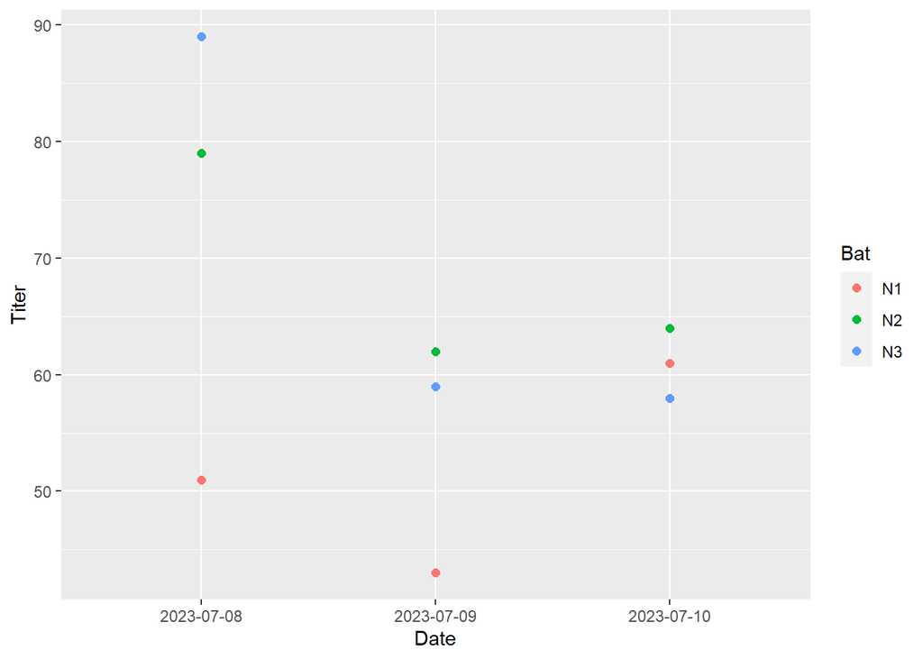

```r
ggplot(mydata, aes(x = Date, y = Titer, colour = Bat)) +
     geom_point(size = 2)
```

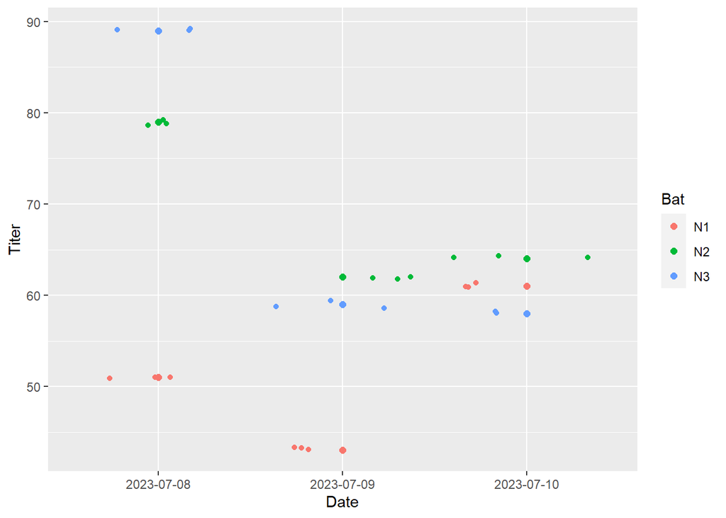

```r
ggplot(mydata, aes(x = Date, y = Titer, colour = Bat)) +
    geom_point(size = 2)+geom_jitter()
```

The points are now visible because *geom_jitter()* adds some **noise** (random variation) to the points. The *amount of jitter* can be controlled by using the **height** and **width** arguments. For example, using smaller values <1 makes the points *tighter* by adding smaller random values, like this:

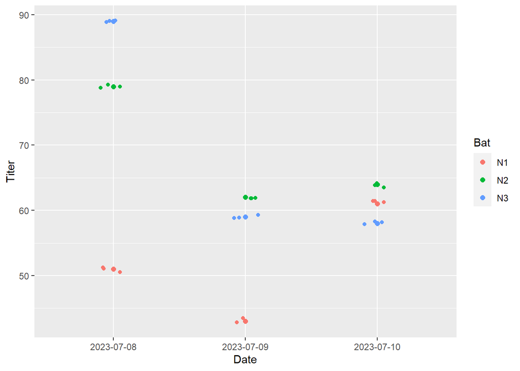

```r
ggplot(mydata, aes(x = Date, y = Titer, colour = Bat)) +
    geom_point(size = 2)+geom_jitter(width = 0.1, height = 0.5)
```

But let’s simulate some more data to make the plots more interesting:

```r
Bat <- c(rep("N1",20),
         rep("N2",20),
         rep("N3",20))

date1 <- seq(from = as.POSIXct("2023-05-01 00:00:00"),
             to = as.POSIXct("2023-05-20 23:45:00"), by = "day")

Date <- rep(date1,3)

Titer <- c(rpois(20,50),
           rpois(20,60),
           rpois(20,70))

mydata <- tibble(Bat, Date, Titer)
```

Now let’s plot these data:

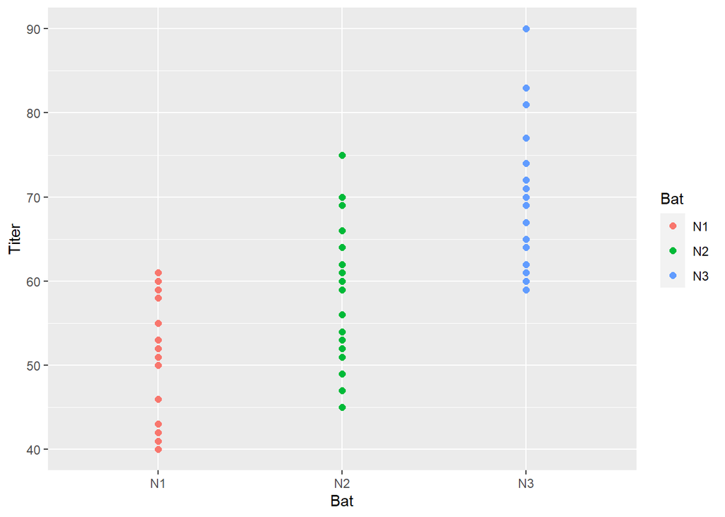

```r
ggplot(mydata, aes(x = Bat, y = Titer, colour = Bat)) +
    geom_point(size = 2)
```

And let’s plot these again using *geom_jitter()*:

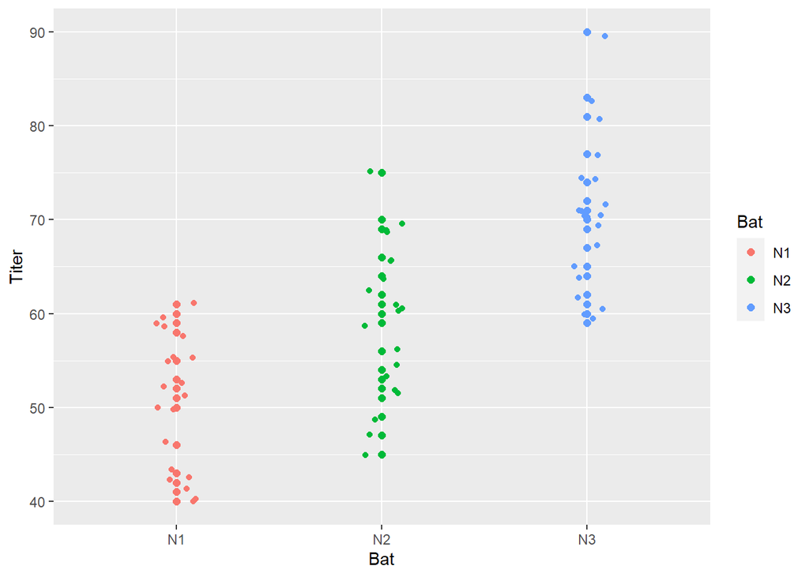

```r
ggplot(mydata, aes(x = Bat, y = Titer, colour = Bat)) +
  geom_point(size = 2)+
  geom_jitter(width = 0.1, height = 0.5)
```

And now let’s plot these data to show the means with standard error for each bat using the **stat_summary()** function:

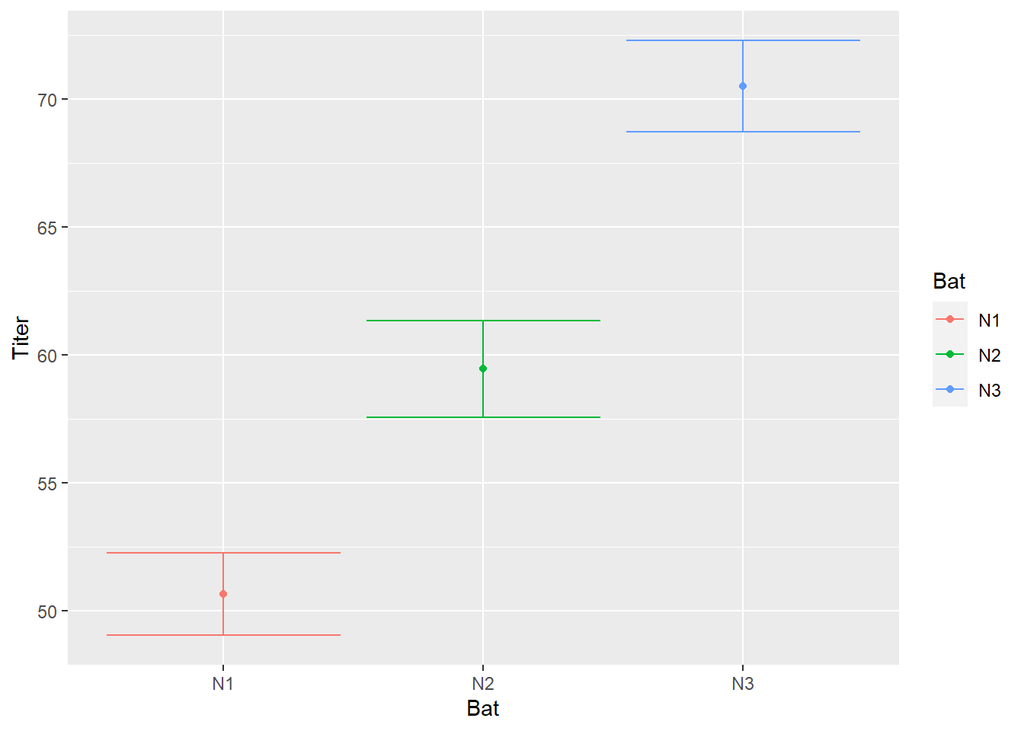

```r
## stats_summary method
ggplot(mydata,              # name of dataset
       aes(x = Bat,        # x-axis variable
           y = Titer,       # y-axis variable
           group = Bat,     # grouping variable (legend)
           color = Bat)) +  # colour
stat_summary(fun = "mean", geom = "point") +  # add data points
stat_summary(fun.data = "mean_se", geom = "errorbar") # add error bars (standard error)
```

The error bars are a bit wide, but we can make plots look better and show more information. Let’s plot these the means with standard error for each bat with the data plotted over them:

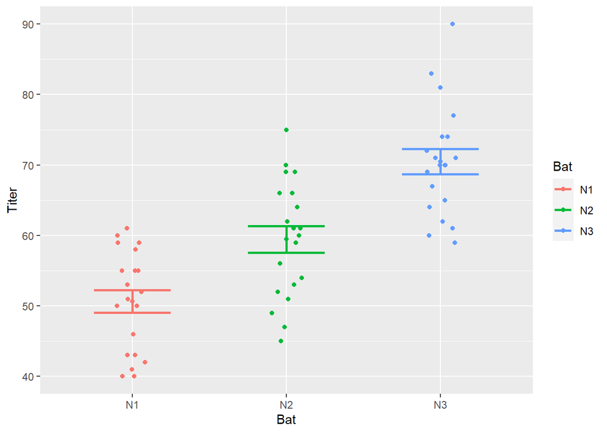

```r
## stats_summary method
ggplot(mydata,              # name of dataset
       aes(x = Bat,        # x-axis variable
           y = Titer,       # y-axis variable
           group = Bat,     # grouping variable (legend)
           color = Bat)) +  # colour
stat_summary(fun = "mean", geom = "point") +  # add data points
stat_summary(fun.data = "mean_se", geom = "errorbar", width = 0.5, linewidth = 1) + # add error bars (standard error)
  geom_jitter(width = 0.1, height = 0)
```

But now it’s hard to see the mean points so we can change the colour of these points by changing the **colour** aesthetic for the mean and making the point larger by using the **size** aesthetic:

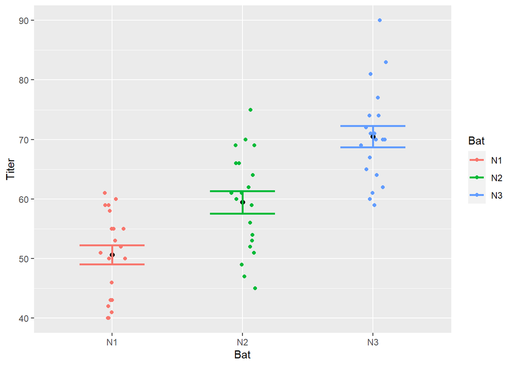

```r
## stats_summary method
ggplot(mydata,              # name of dataset
       aes(x = Bat,        # x-axis variable
           y = Titer,       # y-axis variable
           group = Bat,     # grouping variable (legend)
           color = Bat)) +  # colour
stat_summary(fun = "mean", geom = "point", colour = "black", size = 2) +  # add data points
stat_summary(fun.data = "mean_se", geom = "errorbar", width = 0.5, linewidth = 1) + # add error bars (standard error)
  geom_jitter(width = 0.1, height = 0)
```

It’s still hard to see the mean points and so we can change the colour of the bats too by changing the **colour** aesthetic for the standard error calculation to black:

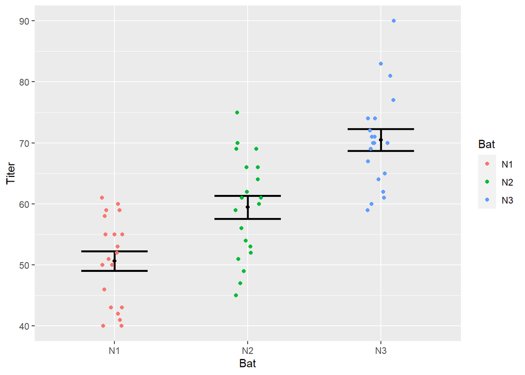

```r
## stats_summary method
ggplot(mydata,              # name of dataset
       aes(x = Bat,        # x-axis variable
           y = Titer,       # y-axis variable
           group = Bat,     # grouping variable (legend)
           color = Bat)) +  # colour
stat_summary(fun = "mean", geom = "point", colour = "black") +  # add data points
stat_summary(fun.data = "mean_se", geom = "errorbar", width = 0.5, linewidth = 1, colour = "black") + # add error bars (standard error)
  geom_jitter(width = 0.1, height = 0)
```

But let’s now switch the colouring all to black by removing the **color =** aesthetic (**aes()**) function from above:

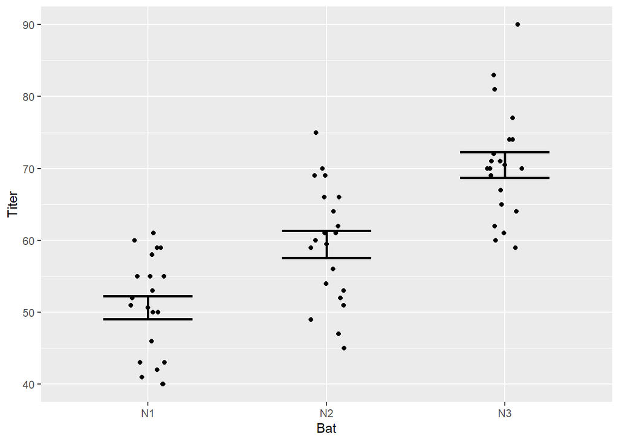

```r
## stats_summary method
ggplot(mydata,              # name of dataset
       aes(x = Bat,        # x-axis variable
           y = Titer,       # y-axis variable
           group = Bat)) +  # colour
stat_summary(fun = "mean", geom = "point") +  # add data points
stat_summary(fun.data = "mean_se", geom = "errorbar", width = 0.5, linewidth = 1) + # add error bars (standard error)
  geom_jitter(width = 0.1, height = 0)
```

This looks cleaner. We will come back to these types of data later when we look at **boxplots** and **violin** plots.

Now let’s plot the means with standard errors through time:

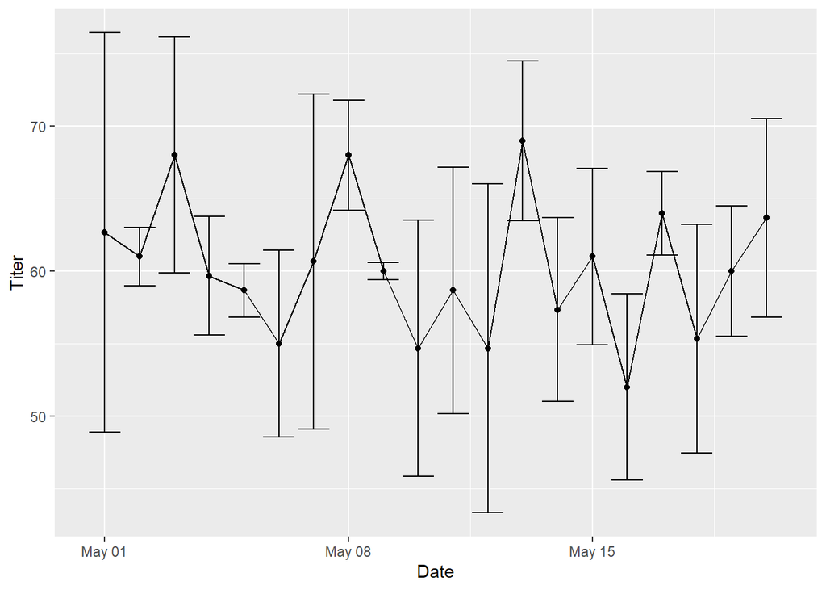

```r
## stats_summary method
ggplot(mydata,
       aes(x = Date,
           y = Titer)) +
  stat_summary(fun = "mean", geom = "point") +
  stat_summary(fun = "mean", geom = "line") +
  stat_summary(fun.data = "mean_se", geom = "errorbar")
```

You can imagine that this could be a plot of the changing antibody titres through time for a population. In reality, if these are from different samples they should probably not have lines linking the points at the different dates, plus this makes the plot look busy. Let’s remove those.

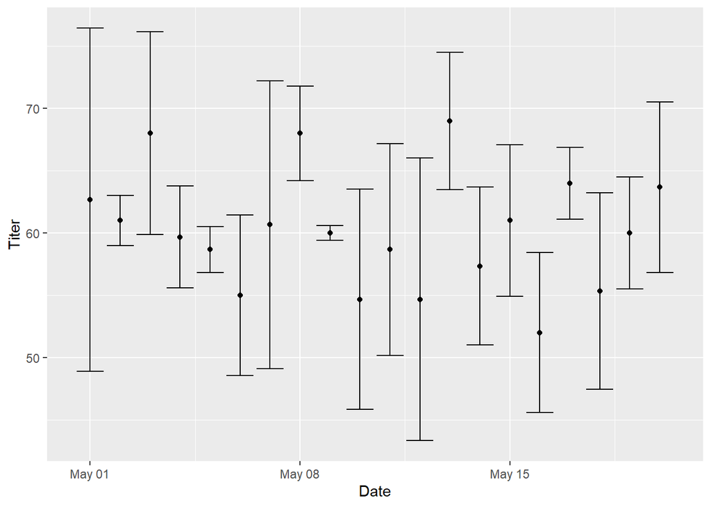

```r
## stats_summary method
ggplot(mydata,
       aes(x = Date,
           y = Titer)) +
  stat_summary(fun = "mean", geom = "point") +
#  stat_summary(fun = "mean", geom = "line") +
  stat_summary(fun.data = "mean_se", geom = "errorbar")
```

Here we can see the data more clearly. Again, remember our data will all look different because we have not used the **set.seed()** function.